# Description

**Dear participant,**

Welcome to the project on Computer vision.

The details of the project can be found with the attached problem statement.

Problem Statement-Plant Seedlings Image Classification using CNN.pdf

Apply the concepts and techniques you have learnt in the previous weeks and summarize your insights at the end.

You need to submit python notebooks in both ".ipynb & HTML" format with proper comments.

Happy Learning!

# Project Description –Image classification using CNNs in Keras

### Data Description:

You are provided with a datasetof images of plant seedlings at various stages of grown. Each image has a filename that is its unique id. The dataset comprises 12 plant species. The goal of the projectis to create a classifier capable of determining a plant's species from a photo.

### Dataset:

The dataset can be download from Olympus. The data file names are:

- images.npy *Label.csv

The original files are from Kaggle. Due to the large volume of data, the images were converted to images.npy file and the labels are also put into the Labels.csv. So that you can work on the data/project seamlessly without worrying about the high data volume.

The followingcode was used to convert the large dataset of images to numpy array:

[output not shown]

Link to the Kaggle project site: https://www.kaggle.com/c/plant-seedlings-classification/data?select=train

**Note: For project purposes, download the data provided on Olympus.**

### Context:

Can you differentiate a weed from a crop seedling?

The ability to do so effectively can mean better crop yields and better stewardship of the environment.

The Aarhus University Signal Processing group, in collaboration with University of Southern Denmark, has recently released a dataset containing images of unique plants belonging to 12 species at several growth stages

## Objective:

To implement the techniques learnt as a part of the course.

#### Learning Outcomes:

- Pre-processing of image data.
- Visualization of images.
- Building CNN.
- Evaluate the Model.
- The motive of the project is to make the learners capable to handle images/image classification problems, during this process you should also be capable to handle real image files, not just limited to a numpy array of image pixels.

### Guide to solve the project seamlessly:

Here are the points which will help you to solve the problem efficiently:

- Read the problem statement carefully from start to end (including the note at the end). The highlighted part in the attached problem statement should not be missed.
- Download the dataset from the Olympus platform.
- Upload the "images.npy" and “Labels.csv” file to google drive.
- Then you can use the dataset path in the Google Colab notebook to do further steps related to project problem statement.
- You can set runtime type to “GPU” in Google Colab, so that the code will run faster as you will be using CNN to fit your model.

### Steps and tasks:

1. Import the libraries, load dataset, print shape of data, visualize the images in dataset. **(5 Marks)**
2. Data Pre-processing: **(15 Marks)**
   - Normalization.
   - Gaussian Blurring.
   - Visualize data after pre-processing.
3. Make data compatible: **(10 Marks)**
   - Convert labels to one-hot-vectors.
   - Print the label for y_train[0].
   - Split the dataset into training, testing, and validation set. (Hint: First split images and labels into training and testing set with test_size = 0.3. Then further split test data into test and validation set with test_size = 0.5)
   - Check the shape of data, Reshape data into shapes compatible with Keras models if it’s not already. If it’s already in the compatible shape, then comment in the notebook that it’s already in compatible shape.
4. Building CNN: **(15 Marks)**
   - Define layers.
   - Set optimizer and loss function. (Use Adam optimizer and categorical crossentropy.)
5. Fit and evaluate model and print confusion matrix. (10 Marks)
6. Visualize predictions for x_test[2], x_test[3], x_test[33], x_test[36], x_test[59]. **(5 Marks)**

**Note:**

- Download the train images from the Olympus Platform.
- Do not download the dataset from Kaggle, as:
  - The dataset is big.
  - The dataset has 2 files for train and test images, but the labels are only for the train file. Test file has no labels associated with it. So, when you want to know the accuracy of model on test images, there’s no way to measure it. That’s why the data provided to you on Olympus has only train images and their labels. For our purpose we use this for our training and testing and validation purpose.

**Happy Learning!**

# Implementation

## 1. Import the libraries, load dataset, print shape of data, visualize the images in dataset. (5 Marks)

Let's break down the tasks into the following steps:

- **Libraries:** We will be working with the following set of libraries:
  - **NumPy & Pandas**: For working with arrays and tabular data.
  - **sklearn**: For metrics & data splitting.
  - **MatplotLib & Seaborn**: For plotting & visualizations
  - **OpenCV**: For image loading, transformations, manipulations (color spaces etc.) and visualizations.
  - **Tensorflow & Keras**: We will be using Tensorflow 2.x and Keras that comes bundled with Tensorflow 2.x for training, model building and predictions using the built models.
  - **Google Colab Helpers and Patches:** We will use these helpers to map google drive as a volume and patch OpenCV to display images inline in the notebook.
- **Load Dataset:** We will be using the data provided on Olympus (`images.npy` and `Labels.csv`) files. For the sake of organization and managing the data in my google drive I have renamed the files as follows (and put them in a namespaced folder):
  - `images.npy` -> `seedlings-images.npy`: The file would available at the path `/content/drive/MyDrive/gl-deep-learning/datasets/seedlings-images.npy` after mapping the google drive.
  - `Labels.csv` -> `seedlings-labels.csv`: The file would available at the path `/content/drive/MyDrive/gl-deep-learning/datasets/seedlings-labels.csv` after mapping the google drive.
- **Visualize a few images:** After loading the data in memory (using numpy) we will use the `imshow()` function of OpenCV to display a few images for each class.

```python
# Cell# 1
# Import the libraries
# for OS features like files & paths
import os
# Data loading
import numpy as np
import pandas as pd

# for visualization
import matplotlib.pyplot as plt
import seaborn as sns
import cv2

# Model Building
import tensorflow as tf
from tensorflow import keras
from tensorflow.keras.models import Sequential #sequential api for sequential model
from tensorflow.keras.layers import Dense, Dropout, Flatten #importing different layers
from tensorflow.keras.layers import Conv2D, MaxPooling2D, BatchNormalization, Activation, Input, LeakyReLU,Activation
from tensorflow.keras import backend as K
from tensorflow.keras.utils import to_categorical #to perform one-hot encoding
from tensorflow.keras.layers import Dense, Dropout, Flatten, Conv2D, MaxPool2D
from tensorflow.keras.optimizers import RMSprop,Adam #optimiers for optimizing the model
from tensorflow.keras.callbacks import EarlyStopping  #regularization method to prevent the overfitting
from tensorflow.keras.callbacks import ModelCheckpoint
from tensorflow.keras.models import Sequential, Model
from tensorflow.keras import losses, optimizers
from keras.preprocessing.image import ImageDataGenerator

# sklearn - for train_test_split, accuracy_score, confusion_matrix and precision_recall_fscore_support
from sklearn.model_selection import train_test_split
from sklearn import metrics
from sklearn.metrics import accuracy_score, confusion_matrix, precision_recall_fscore_support, f1_score
from sklearn.preprocessing import OrdinalEncoder

# Patch for CV2
from google.colab.patches import cv2_imshow
```

```python
# Cell# 2
# Map Google Drive to Load Data: Skip this step if not running in Google Colab
from google.colab import drive
drive.mount('/content/drive')
```

```python
# Cell# 3
# Set data path and load X (independent) & y (dependent) fields of data
X_file_path = '/content/drive/MyDrive/gl-deep-learning/datasets/seedlings-images.npy'
y_file_path = '/content/drive/MyDrive/gl-deep-learning/datasets/seedlings-labels.csv'
X = np.load(X_file_path)
y = pd.read_csv(y_file_path)
```

```python
# Cell# 4
# Print the shape of the data
print(f'X shape: {X.shape}')
print(f'y shape: {y.shape}')
print(f'Unique Values: {y.Label.value_counts()}')
```

```
X shape: (4750, 128, 128, 3)
y shape: (4750, 1)
Unique Values: Loose Silky-bent             654
Common Chickweed             611
Scentless Mayweed            516
Small-flowered Cranesbill    496
Fat Hen                      475
Charlock                     390
Sugar beet                   385
Cleavers                     287
Black-grass                  263
Shepherds Purse              231
Maize                        221
Common wheat                 221
Name: Label, dtype: int64
```

```python
# Cell# 5
# find minimum index for each image type
groupings = y.groupby('Label', axis=0)
image_indices_by_label = pd.DataFrame(columns=['Label', 'MinIndex'])
for a,b in groupings:
  image_indices_by_label = image_indices_by_label.append({'Label': a, 'MinIndex': b.Label.first_valid_index()}, ignore_index=True)
image_indices_by_label.head(20)
```

|  | Label | MinIndex |
| --- | --- | --- |
| 0 | Black-grass | 3833 |
| 1 | Charlock | 2034 |
| 2 | Cleavers | 2424 |
| 3 | Common Chickweed | 1423 |
| 4 | Common wheat | 1202 |
| 5 | Fat Hen | 496 |
| 6 | Loose Silky-bent | 4096 |
| 7 | Maize | 3612 |
| 8 | Scentless Mayweed | 2711 |
| 9 | Shepherds Purse | 971 |
| 10 | Small-flowered Cranesbill | 0 |
| 11 | Sugar beet | 3227 |

```
Label: Black-grass
```

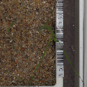

```
Label: Charlock
```

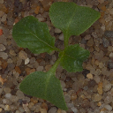

```
Label: Cleavers
```

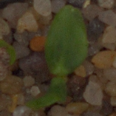

```
Label: Common Chickweed
```

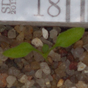

```
Label: Common wheat
```

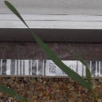

```
Label: Fat Hen
```

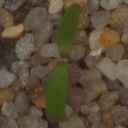

```
Label: Loose Silky-bent
```

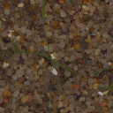

```
Label: Maize
```

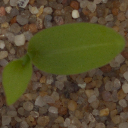

```
Label: Scentless Mayweed
```

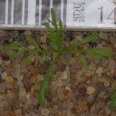

```
Label: Shepherds Purse
```

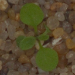

[output not shown]

```
Label: Sugar beet
```

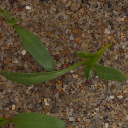

```python
# Cell# 6
# see a sample of each image type
for index, row in image_indices_by_label.iterrows():
  print(f'Label: {row.Label}')
  cv2_imshow(X[row.MinIndex])
```

## Data Pre-processing: (15 Marks)

### Normalization:

- we need to normalize our data as it would make the learning process more robust by having because neural networks process inputs using small weight values, and inputs with large integer values can disrupt or slow down the learning process.
- we can achieve this by dividing the RGB codes with 255 (which is the maximum RGB code minus the minimum RGB code)
- We need to make sure that the values are float so that we can get decimal points after division.

### Gaussian Blurring:

- We can use the [GaussianBlur](https://docs.opencv.org/4.5.0/d4/d86/group__imgproc__filter.html#gaabe8c836e97159a9193fb0b11ac52cf1) available in OpenCV library
- We should specify the width and height of the kernel which should be positive and odd - we are going to use a 3X3 kernel.
- Gaussian blurring is highly effective in removing [Gaussian noise](https://en.wikipedia.org/wiki/Image_noise#Gaussian_noise) from an images.

### Visualize data after pre-processing.

- After applying the above transformations to the image we are are going to visualize a few random images to see the difference.

```
gray image shape: (128, 128, 3)
```

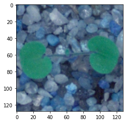

```python
# Cell# 7
# translate the values to float
X_normalized = X.astype('float32')

# Get grascale images
def gray_maker(img):
  return cv2.cvtColor(img, cv2.COLOR_BGR2GRAY)

# X_normalized = np.array([gray_maker(img) for img in X])
# I found that the opencv normalizaion results in a much better image compared to simple normalization (i.e /255 over the np array)
# normalize between 0-1
def normalizer(image):
  norm_image = np.zeros((128, 128))
  return cv2.normalize(image, norm_image, alpha=0, beta=1, norm_type=cv2.NORM_MINMAX, dtype=cv2.CV_32F)

X_normalized = np.array([normalizer(img) for img in X_normalized])
print(f'gray image shape: {X_normalized[0].shape}')
plt.imshow(X_normalized[0])
```

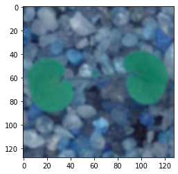

```python
# Cell# 8
# next let's add some gaussian blurring to the images using the opencv gaussian blur function
def blurring(img):
  return cv2.GaussianBlur(img,(3,3),0)
X_normalized_blurred = np.array([blurring(img) for img in X_normalized])
plt.imshow(X_normalized_blurred[0])
```

```
Label: Black-grass
Label: Charlock
Label: Cleavers
Label: Common Chickweed
Label: Common wheat
Label: Fat Hen
Label: Loose Silky-bent
Label: Maize
Label: Scentless Mayweed
Label: Shepherds Purse
Label: Small-flowered Cranesbill
Label: Sugar beet
```

[figure not shown]

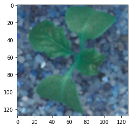

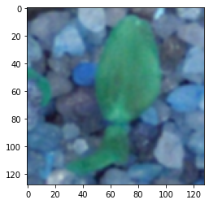

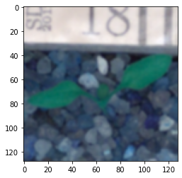

[figure not shown]

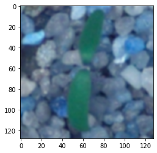

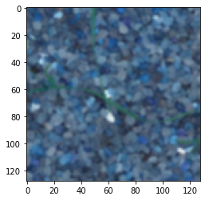

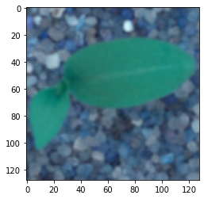

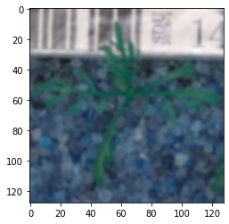

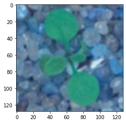

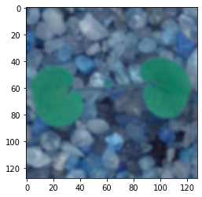

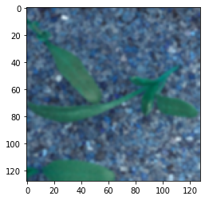

```python
# Cell# 9
# see a sample of each image type
for index, row in image_indices_by_label.iterrows():
  print(f'Label: {row.Label}')
  plt.figure()
  plt.imshow(X_normalized_blurred[row.MinIndex])
```

## Make data compatible: **(10 Marks)**

### 1. Convert labels to one-hot-vectors

- One Hot Encode with Keras

### 2. Print the label for y_train[0].

### 3. Split the dataset into training, testing, and validation set.

- Hint: First split images and labels into training and testing set with test_size = 0.3. Then further split test data into test and validation set with test_size = 0.5

### 4. Check the shape of data, Reshape data into shapes compatible with Keras models if it’s not already. If it’s already in the compatible shape, then comment in the notebook that it’s already in compatible shape.

```python
# Cell# 10
# first let's encode the strings using Label Encoder
enc = OrdinalEncoder()
enc.fit(y)
print(enc.categories_)
y_encoded = enc.transform(np.array(y))
print(f'encoded data shape: {y_encoded.shape}')
y_mapped_df = pd.DataFrame(y)
y_mapped_df['encoded_labels'] = y_encoded
print(f'\n\nFirst label: {y_mapped_df.Label[0]} \tEncoded: {y_mapped_df.encoded_labels[0]}')
print(f'\n\nAll Y Labels: \n{y_mapped_df.head()}')
for index, row in image_indices_by_label.iterrows():
  print(f'Label: {row.Label} \tEncoded: {y_mapped_df.encoded_labels[row.MinIndex]}')
```

```
[array(['Black-grass', 'Charlock', 'Cleavers', 'Common Chickweed',
       'Common wheat', 'Fat Hen', 'Loose Silky-bent', 'Maize',
       'Scentless Mayweed', 'Shepherds Purse',
       'Small-flowered Cranesbill', 'Sugar beet'], dtype=object)]
encoded data shape: (4750, 1)


First label: Small-flowered Cranesbill 	Encoded: 10.0


All Y Labels:
                       Label  encoded_labels
0  Small-flowered Cranesbill            10.0
1  Small-flowered Cranesbill            10.0
2  Small-flowered Cranesbill            10.0
3  Small-flowered Cranesbill            10.0
4  Small-flowered Cranesbill            10.0
Label: Black-grass 	Encoded: 0.0
Label: Charlock 	Encoded: 1.0
Label: Cleavers 	Encoded: 2.0
Label: Common Chickweed 	Encoded: 3.0
Label: Common wheat 	Encoded: 4.0
Label: Fat Hen 	Encoded: 5.0
Label: Loose Silky-bent 	Encoded: 6.0
Label: Maize 	Encoded: 7.0
Label: Scentless Mayweed 	Encoded: 8.0
Label: Shepherds Purse 	Encoded: 9.0
Label: Small-flowered Cranesbill 	Encoded: 10.0
Label: Sugar beet 	Encoded: 11.0
```

```python
# Cell# 11
y_ohe = to_categorical(y_encoded)
print(f'One Hot Encoded Shape: {y_ohe.shape}')
print(f'First Label y[0]: {y_ohe[0]}')
```

```
One Hot Encoded Shape: (4750, 12)
First Label y[0]: [0. 0. 0. 0. 0. 0. 0. 0. 0. 0. 1. 0.]
```

```
Label for y_train[0]: [0. 0. 0. 1. 0. 0. 0. 0. 0. 0. 0. 0.]
Image for X_train[0]:
```

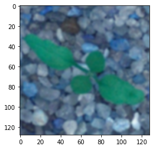

```python
# Cell# 12
#train test split 0.3
# X Final: X_normalized_blurred
# y Final: y_ohe
X_train, X_test, y_train, y_test = train_test_split(X_normalized_blurred, y_ohe, test_size=0.3, random_state = 200)

# print the label for y_train[0] - also show the corresponding image (I am awesome like that)
print(f'Label for y_train[0]: {y_train[0]}')
print('Image for X_train[0]:')
plt.imshow(X_train[0])
```

```
X_train_f shape: (1662, 128, 128, 3)
X_val shape: (1663, 128, 128, 3)
y_train_f shape: (1662, 12)
y_val shape: (1663, 12)
Label for y_train_f[0]: [1. 0. 0. 0. 0. 0. 0. 0. 0. 0. 0. 0.]
Image for X_train[0]:
```

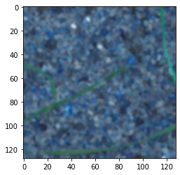

```python
# Cell# 13
# now let's generate a validation set
X_train_f, X_val, y_train_f, y_val = train_test_split(X_train, y_train, test_size=0.5, random_state = 200)
print(f'X_train_f shape: {X_train_f.shape}')
print(f'X_val shape: {X_val.shape}')
print(f'y_train_f shape: {y_train_f.shape}')
print(f'y_val shape: {y_val.shape}')

print(f'Label for y_train_f[0]: {y_train_f[0]}')
print('Image for X_train[0]:')
plt.imshow(X_train_f[0])
```

## Remarks about the shape of the data.

The shape of the data is already in correct format. I am going to create a convolution with all 3 channels (RGB). The images are in the format (128,128,3) and the labels after one hot encoding are a vector of 12 values each.

## Building CNN: (15 Marks)

### Set optimizer and loss function. (Use Adam optimizer and categorical crossentropy.)

```python
# Cell# 14
# Initialising the CNN classifier
classifier = Sequential()

# Add a Convolution layer with 32 kernels of 3X3 shape with activation function ReLU
classifier.add(Conv2D(32, (3, 3), input_shape = (128, 128, 3), activation = 'relu', padding = 'same'))

# Add a Max Pooling layer of size 2X2
classifier.add(MaxPooling2D(pool_size = (2, 2)))

# Add another Convolution layer with 32 kernels of 3X3 shape with activation function ReLU
classifier.add(Conv2D(32, (3, 3), activation = 'relu', padding = 'same'))

# Adding another pooling layer
classifier.add(MaxPooling2D(pool_size = (2, 2)))

# Add another Convolution layer with 32 kernels of 3X3 shape with activation function ReLU
classifier.add(Conv2D(32, (3, 3), activation = 'relu', padding = 'valid'))

# Adding another pooling layer
classifier.add(MaxPooling2D(pool_size = (2, 2)))

# Flattening the layer before fully connected layers
classifier.add(Flatten())

# Adding a fully connected layer with 512 neurons
classifier.add(Dense(units = 512, activation = 'relu'))

# Adding dropout with probability 0.5
classifier.add(Dropout(0.5))


# Adding a fully connected layer with 128 neurons
classifier.add(Dense(units = 128, activation = 'relu'))


# The final output layer with 10 neurons to predict the categorical classifcation
classifier.add(Dense(units = 12, activation = 'softmax'))
```

```python
# Cell# 15
classifier.compile(optimizer = 'adam', loss = 'categorical_crossentropy', metrics = ['accuracy'])
```

```python
# Cell# 16
classifier.summary()
```

```
Model: "sequential"
_________________________________________________________________
Layer (type)                 Output Shape              Param #
=================================================================
conv2d (Conv2D)              (None, 128, 128, 32)      896
_________________________________________________________________
max_pooling2d (MaxPooling2D) (None, 64, 64, 32)        0
_________________________________________________________________
conv2d_1 (Conv2D)            (None, 64, 64, 32)        9248
_________________________________________________________________
max_pooling2d_1 (MaxPooling2 (None, 32, 32, 32)        0
_________________________________________________________________
conv2d_2 (Conv2D)            (None, 30, 30, 32)        9248
_________________________________________________________________
max_pooling2d_2 (MaxPooling2 (None, 15, 15, 32)        0
_________________________________________________________________
flatten (Flatten)            (None, 7200)              0
_________________________________________________________________
dense (Dense)                (None, 512)               3686912
_________________________________________________________________
dropout (Dropout)            (None, 512)               0
_________________________________________________________________
dense_1 (Dense)              (None, 128)               65664
_________________________________________________________________
dense_2 (Dense)              (None, 12)                1548
=================================================================
Total params: 3,773,516
Trainable params: 3,773,516
Non-trainable params: 0
_________________________________________________________________
```

```python
# Cell# 17
# I have split the data into training and validation sets above however for the model building I am going to use the validation_split argument to the fit function - it saves a lot of key strokes :-)
classifier.fit(x=X_train,
               y=y_train,
               steps_per_epoch = int(1662/32),
               epochs = 20,
               validation_split=0.5, verbose=2)
```

```
51/51 - 16s - loss: 2.3288 - accuracy: 0.2136 - val_loss: 2.0297 - val_accuracy: 0.3085
51/51 - 1s - loss: 1.8052 - accuracy: 0.3845 - val_loss: 1.6615 - val_accuracy: 0.4047
51/51 - 1s - loss: 1.5215 - accuracy: 0.4741 - val_loss: 1.4034 - val_accuracy: 0.5021
51/51 - 1s - loss: 1.3757 - accuracy: 0.5162 - val_loss: 1.3970 - val_accuracy: 0.5117
51/51 - 1s - loss: 1.2039 - accuracy: 0.5915 - val_loss: 1.2007 - val_accuracy: 0.5881
51/51 - 1s - loss: 1.0924 - accuracy: 0.6221 - val_loss: 1.1531 - val_accuracy: 0.6055
51/51 - 1s - loss: 1.0045 - accuracy: 0.6432 - val_loss: 1.0417 - val_accuracy: 0.6542
51/51 - 1s - loss: 0.8896 - accuracy: 0.6943 - val_loss: 1.1283 - val_accuracy: 0.6206
51/51 - 1s - loss: 0.7603 - accuracy: 0.7467 - val_loss: 1.0188 - val_accuracy: 0.6639
51/51 - 1s - loss: 0.6500 - accuracy: 0.7671 - val_loss: 0.9560 - val_accuracy: 0.6879
51/51 - 1s - loss: 0.5411 - accuracy: 0.7960 - val_loss: 0.8882 - val_accuracy: 0.7108
51/51 - 1s - loss: 0.5408 - accuracy: 0.8195 - val_loss: 0.9431 - val_accuracy: 0.7078
51/51 - 1s - loss: 0.3880 - accuracy: 0.8712 - val_loss: 1.0398 - val_accuracy: 0.6861
51/51 - 1s - loss: 0.3584 - accuracy: 0.8736 - val_loss: 1.0605 - val_accuracy: 0.7005
51/51 - 1s - loss: 0.2841 - accuracy: 0.9067 - val_loss: 0.9972 - val_accuracy: 0.6993
51/51 - 1s - loss: 0.2441 - accuracy: 0.9260 - val_loss: 1.0704 - val_accuracy: 0.7102
51/51 - 1s - loss: 0.2858 - accuracy: 0.9049 - val_loss: 1.0756 - val_accuracy: 0.6993
51/51 - 1s - loss: 0.1629 - accuracy: 0.9416 - val_loss: 1.2606 - val_accuracy: 0.7078
51/51 - 1s - loss: 0.1472 - accuracy: 0.9489 - val_loss: 1.2425 - val_accuracy: 0.6945
51/51 - 1s - loss: 0.1325 - accuracy: 0.9537 - val_loss: 1.3434 - val_accuracy: 0.7138
```

```
<keras.callbacks.History at 0x7fe9a0169050>
```

```python
# Cell# 19
# try early stopping
model_metrics = [
      keras.metrics.BinaryAccuracy(name='accuracy'),
      keras.metrics.Precision(name='precision'),
      keras.metrics.Recall(name='recall'),
      keras.metrics.AUC(name='auc'),
      keras.metrics.AUC(name='prc', curve='PR')
]
early_stopping = tf.keras.callbacks.EarlyStopping(
    monitor='val_accuracy',
    verbose=1,
    patience=10,
    mode='max',
    restore_best_weights=True)
training_history = classifier.fit(x=X_train,
               y=y_train,
               steps_per_epoch = int(1662/32),
               callbacks=[early_stopping],
               epochs = 50,
               validation_split=0.5, verbose=2)
```

```
51/51 - 1s - loss: 0.1585 - accuracy: 0.9428 - val_loss: 1.5725 - val_accuracy: 0.6500
51/51 - 1s - loss: 0.1731 - accuracy: 0.9392 - val_loss: 1.1158 - val_accuracy: 0.7096
51/51 - 1s - loss: 0.0991 - accuracy: 0.9699 - val_loss: 1.2729 - val_accuracy: 0.7132
51/51 - 1s - loss: 0.0798 - accuracy: 0.9717 - val_loss: 1.4861 - val_accuracy: 0.7066
51/51 - 1s - loss: 0.1159 - accuracy: 0.9567 - val_loss: 1.6217 - val_accuracy: 0.6885
51/51 - 1s - loss: 0.1195 - accuracy: 0.9627 - val_loss: 1.4149 - val_accuracy: 0.6993
51/51 - 1s - loss: 0.0825 - accuracy: 0.9765 - val_loss: 1.5627 - val_accuracy: 0.7126
51/51 - 1s - loss: 0.0700 - accuracy: 0.9777 - val_loss: 1.5440 - val_accuracy: 0.6999
51/51 - 1s - loss: 0.0662 - accuracy: 0.9789 - val_loss: 1.6175 - val_accuracy: 0.7126
51/51 - 1s - loss: 0.0627 - accuracy: 0.9783 - val_loss: 1.5375 - val_accuracy: 0.7168
51/51 - 1s - loss: 0.0459 - accuracy: 0.9850 - val_loss: 1.6126 - val_accuracy: 0.7162
51/51 - 1s - loss: 0.0560 - accuracy: 0.9832 - val_loss: 1.4924 - val_accuracy: 0.7270
51/51 - 1s - loss: 0.0468 - accuracy: 0.9838 - val_loss: 1.6718 - val_accuracy: 0.7198
51/51 - 1s - loss: 0.0658 - accuracy: 0.9801 - val_loss: 1.5369 - val_accuracy: 0.7204
51/51 - 1s - loss: 0.0563 - accuracy: 0.9826 - val_loss: 1.8266 - val_accuracy: 0.6981
51/51 - 1s - loss: 0.1071 - accuracy: 0.9645 - val_loss: 2.0036 - val_accuracy: 0.6597
51/51 - 1s - loss: 0.0706 - accuracy: 0.9765 - val_loss: 1.6185 - val_accuracy: 0.7005
51/51 - 1s - loss: 0.0650 - accuracy: 0.9801 - val_loss: 1.5842 - val_accuracy: 0.7186
51/51 - 1s - loss: 0.0541 - accuracy: 0.9838 - val_loss: 1.5947 - val_accuracy: 0.6957
51/51 - 1s - loss: 0.0577 - accuracy: 0.9826 - val_loss: 1.6332 - val_accuracy: 0.7054
51/51 - 1s - loss: 0.0449 - accuracy: 0.9850 - val_loss: 1.6976 - val_accuracy: 0.7132
51/51 - 1s - loss: 0.0309 - accuracy: 0.9898 - val_loss: 1.8423 - val_accuracy: 0.7090
Restoring model weights from the end of the best epoch.
Epoch 00022: early stopping
```

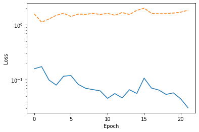

```python
# Cell# 20
def see_loss(history, label, n):
  # Use a log scale on y-axis to show the wide range of values.
  plt.semilogy(history.epoch, history.history['loss'],
               label='Train ' + label)
  plt.semilogy(history.epoch, history.history['val_loss'],
               label='Val ' + label,
               linestyle="--")
  plt.xlabel('Epoch')
  plt.ylabel('Loss')

see_loss(training_history, 'Loss', 0)
```

```python
# Cell# 21
# predict using model
y_pred_1 = classifier.predict(X_test)
y_pred_1.shape
```

```
(1425, 12)
```

```python
# Cell# 22
classifier.evaluate(X_test, y_test)
```

```
[1.5015088319778442, 0.7200000286102295]
```

```python
# Cell# 23
y_test_e = np.argmax(y_test, axis=1)
y_pred_1_e = np.argmax(y_pred_1, axis=1)
plants = ['Black-grass', 'Charlock', 'Cleavers', 'Common Chickweed', 'Common wheat', 'Fat Hen', 'Loose Silky-bent', 'Maize', 'Scentless Mayweed', 'Shepherds Purse', 'Small-flowered Cranesbill', 'Sugar beet']
classification_metrics = metrics.classification_report(y_test_e, y_pred_1_e, target_names=plants)
print(classification_metrics)
```

```
                           precision    recall  f1-score   support

              Black-grass       0.39      0.19      0.25        85
                 Charlock       0.89      0.75      0.82       121
                 Cleavers       0.65      0.88      0.75        97
         Common Chickweed       0.82      0.87      0.84       187
             Common wheat       0.62      0.69      0.65        68
                  Fat Hen       0.64      0.67      0.66       144
         Loose Silky-bent       0.64      0.84      0.73       180
                    Maize       0.82      0.50      0.62        66
        Scentless Mayweed       0.72      0.77      0.74       146
          Shepherds Purse       0.67      0.49      0.57        61
Small-flowered Cranesbill       0.84      0.84      0.84       149
               Sugar beet       0.75      0.64      0.69       121

                 accuracy                           0.72      1425
                macro avg       0.70      0.68      0.68      1425
             weighted avg       0.72      0.72      0.71      1425
```

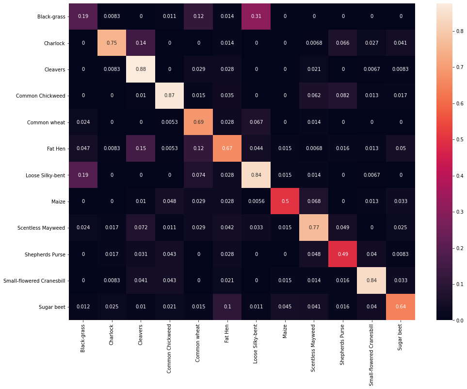

```python
# Cell# 24
cf_matrix = confusion_matrix(np.array(y_test_e), y_pred_1_e)
cf_matrix_n1 = cf_matrix/np.sum(cf_matrix, axis=1)
plt.figure(figsize=(16,12))
sns.heatmap(cf_matrix_n1, xticklabels=plants, yticklabels=plants, annot=True)
```